# Women’s world cup 2023

Ian Hamilton

Stefan Stein

David Selby

July 2023

```r
library(tidyverse)
library(readxl)
library(parallel)
```

```r
First_round_odds <- read_excel("data/First round odds.xlsx") %>%
  rename(
    "odds_1" = "Home win",
    "odds_draw" = "Draw",
    "odds_2" = "Away win",
    "TeamName1" = "Home",
    "TeamName2" = "Away"
  ) %>%
  mutate(TeamName2 = ifelse(TeamName2 == "Republic of Ireland", "Ireland", TeamName2))%>%
  mutate(
    p_ij = 1 / odds_1,
    p_draw = 1 / odds_draw,
    p_ji = 1 / odds_2,
    total_prob = p_ij + p_draw + p_ji
  ) %>%
  mutate(p_ij = p_ij / total_prob,
         p_draw = p_draw / total_prob,
         p_ji = p_ji / total_prob) %>%
  select(-total_prob) %>%
  mutate(s_ij = p_ij / p_ji)
```

```r
p_ij <- First_round_odds[1,"p_ij"]%>%as.numeric()
p_draw <- First_round_odds[1,"p_draw"]%>%as.numeric()
s_ij <- First_round_odds[1,"s_ij"]%>%as.numeric()
```

```r
target_function_beat <- function(p_ij,s_ij,nu){
  s_ij / (s_ij + 1 + nu*sqrt(s_ij)) - p_ij
}
target_function_draw <- function(p_draw,s_ij,nu){
  nu*sqrt(s_ij) / (s_ij + 1 + nu*sqrt(s_ij)) - p_draw
}
root_beat <- uniroot(target_function_beat, p_ij=p_ij,s_ij=s_ij,interval = c(-1,1))
root_draw <- uniroot(target_function_draw, p_draw=p_draw,s_ij=s_ij,interval = c(-1,1))
nu_fn_beat <- function(p_ij, s_ij){
  uniroot(target_function_beat, p_ij=p_ij,s_ij=s_ij,interval = c(-1,1))[['root']]
}
nu_fn_draw <- function(p_draw, s_ij){
  uniroot(target_function_draw, p_draw=p_draw,s_ij=s_ij,interval = c(-1,1))[['root']]
}
```

```r
df <- First_round_odds %>%
  rowwise() %>%
  mutate(nu_beat = nu_fn_beat(p_ij,s_ij),
         nu_draw = nu_fn_draw(p_draw,s_ij)) %>%
  ungroup()
df
```

| TeamName1 | TeamName2 | odds_1 | odds_draw | odds_2 | p_ij | p_draw | p_ji | s_ij | nu_beat | nu_draw |
| --- | --- | --- | --- | --- | --- | --- | --- | --- | --- | --- |
| New Zealand | Norway | 11.00 | 6.00 | 1.32 | 0.0895522 | 0.1641791 | 0.7462687 | 0.1200000 | 0.6350870 | 0.6350870 |
| Australia | Ireland | 1.30 | 5.50 | 11.00 | 0.7382550 | 0.1744966 | 0.0872483 | 8.4615385 | 0.6875528 | 0.6875528 |
| Nigeria | Canada | 11.00 | 5.50 | 1.32 | 0.0882353 | 0.1764706 | 0.7352941 | 0.1200000 | 0.6928215 | 0.6928215 |
| Philippines | Switzerland | 21.00 | 8.50 | 1.17 | 0.0466869 | 0.1153440 | 0.8379692 | 0.0557143 | 0.5831546 | 0.5831546 |
| Spain | Costa Rica | 1.03 | 51.00 | 151.00 | 0.9736935 | 0.0196648 | 0.0066418 | 146.6019417 | 0.2445355 | 0.2445355 |
| USA | Vietnam | 1.01 | 126.00 | 201.00 | 0.9871271 | 0.0079127 | 0.0049602 | 199.0099010 | 0.1130822 | 0.1130822 |
| Zambia | Japan | 12.00 | 7.50 | 1.24 | 0.0814503 | 0.1303205 | 0.7882291 | 0.1033333 | 0.5143300 | 0.5143300 |
| England | Haiti | 1.02 | 51.00 | 101.00 | 0.9707805 | 0.0194156 | 0.0098039 | 99.0196078 | 0.1990250 | 0.1990250 |
| Denmark | China | 1.55 | 4.33 | 6.20 | 0.6219031 | 0.2226212 | 0.1554758 | 4.0000000 | 0.7159402 | 0.7159402 |
| Sweden | South Africa | 1.10 | 11.00 | 41.00 | 0.8874459 | 0.0887446 | 0.0238095 | 37.2727273 | 0.6105300 | 0.6105300 |
| Netherlands | Portugal | 1.44 | 4.75 | 7.50 | 0.6688257 | 0.2027598 | 0.1284145 | 5.2083333 | 0.6918636 | 0.6918636 |
| France | Jamaica | 1.03 | 26.00 | 67.00 | 0.9478776 | 0.0375505 | 0.0145718 | 65.0485437 | 0.3195249 | 0.3195249 |
| Italy | Argentina | 1.55 | 5.50 | 6.50 | 0.6577737 | 0.1853726 | 0.1568537 | 4.1935484 | 0.5771223 | 0.5771223 |
| Germany | Morocco | 1.05 | 18.00 | 67.00 | 0.9310944 | 0.0543138 | 0.0145918 | 63.8095238 | 0.4659820 | 0.4659820 |
| Brazil | Panama | 1.03 | 34.00 | 81.00 | 0.9587634 | 0.0290449 | 0.0121917 | 78.6407767 | 0.2686589 | 0.2686589 |
| Colombia | South Korea | 2.63 | 3.30 | 2.90 | 0.3698408 | 0.2947519 | 0.3354073 | 1.1026616 | 0.8368836 | 0.8368836 |

```r
summary(df$nu_beat)
```

```
##    Min. 1st Qu.  Median    Mean 3rd Qu.    Max.
##  0.1131  0.3068  0.5801  0.5098  0.6886  0.8369
```

```r
# based on 10 matches
odds_threshold <- 1.1
df%>%filter(odds_1 >= odds_threshold,
            odds_2 >= odds_threshold)%>%
  pull(nu_beat)%>%
  summary()
```

```
##    Min. 1st Qu.  Median    Mean 3rd Qu.    Max.
##  0.5143  0.5900  0.6613  0.6545  0.6926  0.8369
```

```r
nu <- df%>%filter(odds_1 >= odds_threshold,
            odds_2 >= odds_threshold)%>%
  pull(nu_beat)%>%
  summary()

nu <- nu["Mean"]
nu
```

```
##      Mean
## 0.6545286
```

```r
# based on 7 matches
odds_threshold <- 1.3
df%>%filter(odds_1 >= odds_threshold,
            odds_2 >= odds_threshold)%>%
  pull(nu_beat)%>%
  summary()
```

```
##    Min. 1st Qu.  Median    Mean 3rd Qu.    Max.
##  0.5771  0.6613  0.6919  0.6910  0.7044  0.8369
```

# Fifa rankings

## Getting sigma

```r
Fifa_rating <- read_csv("data/Fifa rating.csv")
```

```r
df <- df%>%
  left_join(Fifa_rating%>%rename("F_i" = "Fifa rating"),by=c("TeamName1"="Team"))%>%
  left_join(Fifa_rating%>%rename("F_j" = "Fifa rating"),by=c("TeamName2"="Team"))
```

```r
df <- df%>%
  mutate(sigma = (F_i - F_j) / log10((p_ji + 0.5*p_draw)/(p_ij + 0.5*p_draw)))
```

```r
summary(df$sigma)
```

```
##    Min. 1st Qu.  Median    Mean 3rd Qu.    Max.
## -808.35 -463.31 -330.39  -62.91 -252.75 4599.88
```

```r
summary(df$sigma[1:15])
```

```
##    Min. 1st Qu.  Median    Mean 3rd Qu.    Max.
## -808.35 -478.58 -332.38 -373.76 -265.92  -26.78
```

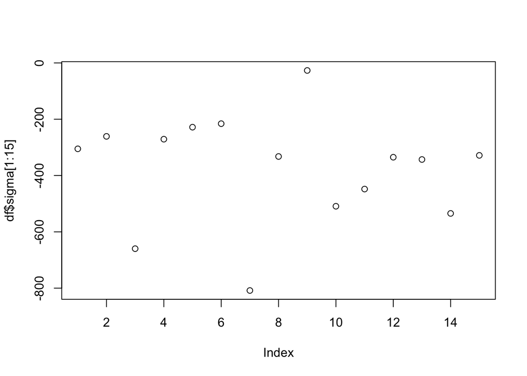

```r
plot(df$sigma[1:15])
```

Here I am doing a regression of

$$F_i - F_j = \log \left(\frac{p_{ji}+0.5 p_{i \sim j}}{p_{ij}+0.5p_{i
\sim j}} \right)\sigma'$$
to get an estimate of $\sigma'$.

```r
M <- df%>%
  transmute(X = log10((p_ji + 0.5*p_draw)/(p_ij + 0.5*p_draw)),
            Y = (F_i - F_j))

M <- M[1:15,]

lmfit <- lm(Y ~ -1 + X, data = M)
sigma_dash <- coef(lmfit)
summary(lmfit)
```

```
##
## Call:
## lm(formula = Y ~ -1 + X, data = M)
##
## Residuals:
##     Min      1Q  Median      3Q     Max
## -361.14 -163.86   -6.59   40.01  269.89
##
## Coefficients:
##   Estimate Std. Error t value Pr(>|t|)
## X  -336.26      37.16   -9.05 3.17e-07 ***
## ---
## Signif. codes:  0 '***' 0.001 '**' 0.01 '*' 0.05 '.' 0.1 ' ' 1
##
## Residual standard error: 172.2 on 14 degrees of freedom
## Multiple R-squared:  0.854,  Adjusted R-squared:  0.8436
## F-statistic:  81.9 on 1 and 14 DF,  p-value: 3.171e-07
```

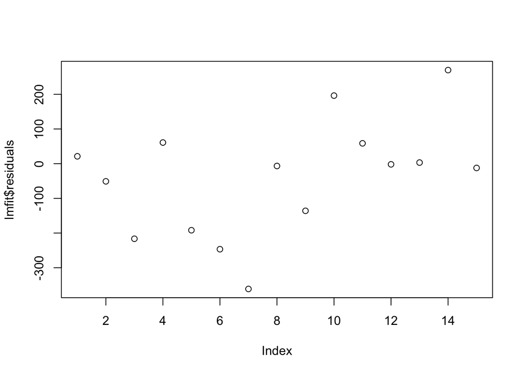

```r
plot(lmfit$residuals)
```

## Getting alpha

```r
Group_Winner_odds <- read_excel("data/Group Winner odds.xlsx")
```

```r
get_group_matches <- function(group){
  Group_Winner_odds%>%
  filter(Group == group)%>%
  pull(Team)%>%
  combn(m=2)%>%
  t()%>%
  as.data.frame()%>%
  mutate(group = group)
}
groups <- LETTERS[1:8]

group_matches <- lapply(groups, get_group_matches)%>%
  do.call(rbind, .)%>%
  rename("TeamName1" = "V1", "TeamName2" = "V2") %>%
  rowwise() %>%
  mutate(match_string = sort(c(TeamName1,TeamName2))%>%paste(collapse = "-"))%>%
  ungroup()
```

```r
find_sij <- function(alpha_ij, s_ij){
  (s_ij + 0.5 * nu * sqrt(s_ij)) / (s_ij + 1 + nu*sqrt(s_ij)) - alpha_ij
}
sij_fn <- function(alpha_ij){
  uniroot(find_sij, alpha_ij=alpha_ij,interval = c(0,10000))[['root']]
}


estimated_df <- group_matches%>%
  select(-c(TeamName1,TeamName2))%>%
  left_join(
    df%>%
      rowwise()%>%
      mutate(match_string = sort(c(TeamName1,TeamName2))%>%paste(collapse = "-"))%>%
      ungroup(),
    by = "match_string"
  )%>%
  rowwise()%>%
  mutate(TeamName1 = ifelse(is.na(TeamName1), str_split(match_string, pattern="-", simplify = T)[1], TeamName1),
         TeamName2 = ifelse(is.na(TeamName2), str_split(match_string, pattern="-", simplify = T)[2], TeamName2))%>%
  ungroup()%>%
  # drop Fifa rankings here to join them back for all matches in next step
  select(-c(F_i,F_j, sigma))%>%
  select(-starts_with("nu"))%>%
  left_join(Fifa_rating%>%rename("F_i" = "Fifa rating"),by=c("TeamName1"="Team"))%>%
  left_join(Fifa_rating%>%rename("F_j" = "Fifa rating"),by=c("TeamName2"="Team"))%>%
  mutate(alpha_ij = 1 / (1 + 10^((F_i - F_j)/ sigma_dash))) %>%
  rowwise()%>%
  mutate(s_ij = ifelse(is.na(s_ij),sij_fn(alpha_ij),s_ij))%>%
  ungroup()%>%
  # now add the missing probs
  mutate(p_ij = ifelse(is.na(p_ij),s_ij/(s_ij + 1 + nu*sqrt(s_ij)),p_ij),
         p_draw = ifelse(is.na(p_draw),nu*sqrt(s_ij)/(s_ij + 1 + nu*sqrt(s_ij)),p_draw),
         p_ji = ifelse(is.na(p_ji),1-p_ij-p_draw,p_ji),
         total_prob = p_ij + p_draw + p_ji,
         logit_p_ij = log(p_ij / p_ji))
```

```r
estimated_df
```

| group | match_string | TeamName1 | TeamName2 | odds_1 | odds_draw | odds_2 | p_ij | p_draw | p_ji | s_ij | F_i | F_j | alpha_ij | total_prob | logit_p_ij |
| --- | --- | --- | --- | --- | --- | --- | --- | --- | --- | --- | --- | --- | --- | --- | --- |
| A | Norway-Switzerland | Norway | Switzerland | NA | NA | NA | 0.6203516 | 0.2114353 | 0.1682131 | 3.6878915 | 1908.25 | 1765.90 | 0.7260693 | 1 | 1.3050549 |
| A | New Zealand-Norway | New Zealand | Norway | 11.00 | 6.00 | 1.32 | 0.0895522 | 0.1641791 | 0.7462687 | 0.1200000 | 1699.70 | 1908.25 | 0.1933968 | 1 | -2.1202635 |
| A | Norway-Philippines | Norway | Philippines | NA | NA | NA | 0.8942817 | 0.0862852 | 0.0194331 | 46.0185639 | 1908.25 | 1512.97 | 0.9374243 | 1 | 3.8290449 |
| A | New Zealand-Switzerland | New Zealand | Switzerland | NA | NA | NA | 0.2693959 | 0.2383516 | 0.4922525 | 0.5472719 | 1699.70 | 1765.90 | 0.3885722 | 1 | -0.6028096 |
| A | Philippines-Switzerland | Philippines | Switzerland | 21.00 | 8.50 | 1.17 | 0.0466869 | 0.1153440 | 0.8379692 | 0.0557143 | 1512.97 | 1765.90 | 0.1503333 | 1 | -2.8875187 |
| A | New Zealand-Philippines | New Zealand | Philippines | NA | NA | NA | 0.6871814 | 0.1900846 | 0.1227341 | 5.5989454 | 1699.70 | 1512.97 | 0.7822235 | 1 | 1.7225783 |
| B | Australia-Canada | Australia | Canada | NA | NA | NA | 0.2538950 | 0.2356354 | 0.5104696 | 0.4973753 | 1919.69 | 1996.34 | 0.3717127 | 1 | -0.6984104 |
| B | Australia-Ireland | Australia | Ireland | 1.30 | 5.50 | 11.00 | 0.7382550 | 0.1744966 | 0.0872483 | 8.4615385 | 1919.69 | 1743.59 | 0.7695692 | 1 | 2.1355310 |
| B | Australia-Nigeria | Australia | Nigeria | NA | NA | NA | 0.8743089 | 0.0993429 | 0.0263482 | 33.1828521 | 1919.69 | 1554.94 | 0.9239804 | 1 | 3.5020332 |
| B | Canada-Ireland | Canada | Ireland | NA | NA | NA | 0.7718917 | 0.1552352 | 0.0728730 | 10.5922814 | 1996.34 | 1743.59 | 0.8495092 | 1 | 2.3601256 |
| B | Canada-Nigeria | Nigeria | Canada | 11.00 | 5.50 | 1.32 | 0.0882353 | 0.1764706 | 0.7352941 | 0.1200000 | 1554.94 | 1996.34 | 0.0464163 | 1 | -2.1202635 |
| B | Ireland-Nigeria | Ireland | Nigeria | NA | NA | NA | 0.6899027 | 0.1891046 | 0.1209927 | 5.7020197 | 1743.59 | 1554.94 | 0.7844549 | 1 | 1.7408204 |
| C | Japan-Spain | Japan | Spain | NA | NA | NA | 0.2410063 | 0.2330339 | 0.5259598 | 0.4582218 | 1916.68 | 2002.28 | 0.3575157 | 1 | -0.7804019 |
| C | Spain-Zambia | Spain | Zambia | NA | NA | NA | 0.9845337 | 0.0149373 | 0.0005290 | 1861.1146453 | 2002.28 | 1298.31 | 0.9920023 | 1 | 7.5289309 |
| C | Costa Rica-Spain | Spain | Costa Rica | 1.03 | 51.00 | 151.00 | 0.9736935 | 0.0196648 | 0.0066418 | 146.6019417 | 2002.28 | 1596.94 | 0.9413456 | 1 | 4.9877210 |
| C | Japan-Zambia | Zambia | Japan | 12.00 | 7.50 | 1.24 | 0.0814503 | 0.1303205 | 0.7882291 | 0.1033333 | 1298.31 | 1916.68 | 0.0142814 | 1 | -2.2697953 |
| C | Costa Rica-Japan | Costa Rica | Japan | NA | NA | NA | 0.0404283 | 0.1205476 | 0.8390241 | 0.0481849 | 1596.94 | 1916.68 | 0.1006988 | 1 | -3.0327094 |
| C | Costa Rica-Zambia | Costa Rica | Zambia | NA | NA | NA | 0.8198515 | 0.1311654 | 0.0489831 | 16.7374434 | 1596.94 | 1298.31 | 0.8854342 | 1 | 2.8176483 |
| D | Denmark-England | Denmark | England | NA | NA | NA | 0.1342516 | 0.1962317 | 0.6695168 | 0.2005201 | 1866.25 | 2040.76 | 0.2323672 | 1 | -1.6068405 |
| D | China-England | China | England | NA | NA | NA | 0.1231541 | 0.1903189 | 0.6865270 | 0.1793871 | 1854.49 | 2040.76 | 0.2183136 | 1 | -1.7182091 |
| D | England-Haiti | England | Haiti | 1.02 | 51.00 | 101.00 | 0.9707805 | 0.0194156 | 0.0098039 | 99.0196078 | 2040.76 | 1475.33 | 0.9796057 | 1 | 4.5953179 |
| D | China-Denmark | Denmark | China | 1.55 | 4.33 | 6.20 | 0.6219031 | 0.2226212 | 0.1554758 | 4.0000000 | 1866.25 | 1854.49 | 0.5201214 | 1 | 1.3862944 |
| D | Denmark-Haiti | Denmark | Haiti | NA | NA | NA | 0.8916102 | 0.0880795 | 0.0203103 | 43.8993169 | 1866.25 | 1475.33 | 0.9356499 | 1 | 3.7818988 |
| D | China-Haiti | China | Haiti | NA | NA | NA | 0.8841092 | 0.0930374 | 0.0228534 | 38.6860431 | 1854.49 | 1475.33 | 0.9306279 | 1 | 3.6554789 |
| E | Netherlands-USA | Netherlands | USA | NA | NA | NA | 0.2079656 | 0.2248040 | 0.5672304 | 0.3666333 | 1980.47 | 2090.30 | 0.3203676 | 1 | -1.0033930 |
| E | Portugal-USA | Portugal | USA | NA | NA | NA | 0.0318408 | 0.1083014 | 0.8598577 | 0.0370304 | 1745.13 | 2090.30 | 0.0859892 | 1 | -3.2960169 |
| E | USA-Vietnam | USA | Vietnam | 1.01 | 126.00 | 201.00 | 0.9871271 | 0.0079127 | 0.0049602 | 199.0099010 | 2090.30 | 1648.89 | 0.9535867 | 1 | 5.2933546 |
| E | Netherlands-Portugal | Netherlands | Portugal | 1.44 | 4.75 | 7.50 | 0.6688257 | 0.2027598 | 0.1284145 | 5.2083333 | 1980.47 | 1745.13 | 0.8336248 | 1 | 1.6502599 |
| E | Netherlands-Vietnam | Netherlands | Vietnam | NA | NA | NA | 0.8490281 | 0.1147625 | 0.0362094 | 23.4477498 | 1980.47 | 1648.89 | 0.9064094 | 1 | 3.1547745 |
| E | Portugal-Vietnam | Portugal | Vietnam | NA | NA | NA | 0.5442293 | 0.2296231 | 0.2261476 | 2.4065227 | 1745.13 | 1648.89 | 0.6590408 | 1 | 0.8781828 |
| F | Brazil-France | Brazil | France | NA | NA | NA | 0.3241880 | 0.2446948 | 0.4311171 | 0.7519721 | 1995.30 | 2026.65 | 0.4465363 | 1 | -0.2850561 |
| F | France-Jamaica | France | Jamaica | 1.03 | 26.00 | 67.00 | 0.9478776 | 0.0375505 | 0.0145718 | 65.0485437 | 2026.65 | 1536.81 | 0.9662446 | 1 | 4.1751338 |
| F | France-Panama | France | Panama | NA | NA | NA | 0.9567566 | 0.0394470 | 0.0037964 | 252.0182481 | 2026.65 | 1482.51 | 0.9764801 | 1 | 5.5295015 |
| F | Brazil-Jamaica | Brazil | Jamaica | NA | NA | NA | 0.9269917 | 0.0630107 | 0.0099976 | 92.7215455 | 1995.30 | 1536.81 | 0.9584971 | 1 | 4.5296009 |
| F | Brazil-Panama | Brazil | Panama | 1.03 | 34.00 | 81.00 | 0.9587634 | 0.0290449 | 0.0121917 | 78.6407767 | 1995.30 | 1482.51 | 0.9710113 | 1 | 4.3648904 |
| F | Jamaica-Panama | Jamaica | Panama | NA | NA | NA | 0.4713999 | 0.2410003 | 0.2875998 | 1.6390832 | 1536.81 | 1482.51 | 0.5919011 | 1 | 0.4941371 |
| G | Italy-Sweden | Italy | Sweden | NA | NA | NA | 0.1083795 | 0.1815710 | 0.7100496 | 0.1526365 | 1846.50 | 2049.71 | 0.1991650 | 1 | -1.8796962 |
| G | Argentina-Sweden | Argentina | Sweden | NA | NA | NA | 0.0257082 | 0.0982274 | 0.8760643 | 0.0293452 | 1682.45 | 2049.71 | 0.0748211 | 1 | -3.5286276 |
| G | South Africa-Sweden | Sweden | South Africa | 1.10 | 11.00 | 41.00 | 0.8874459 | 0.0887446 | 0.0238095 | 37.2727273 | 2049.71 | 1471.52 | 0.9812801 | 1 | 3.6182619 |
| G | Argentina-Italy | Italy | Argentina | 1.55 | 5.50 | 6.50 | 0.6577737 | 0.1853726 | 0.1568537 | 4.1935484 | 1846.50 | 1682.45 | 0.7546124 | 1 | 1.4335472 |
| G | Italy-South Africa | Italy | South Africa | NA | NA | NA | 0.8813367 | 0.0948406 | 0.0238226 | 36.9957555 | 1846.50 | 1471.52 | 0.9287570 | 1 | 3.6108032 |
| G | Argentina-South Africa | Argentina | South Africa | NA | NA | NA | 0.7203745 | 0.1775167 | 0.1021088 | 7.0549709 | 1682.45 | 1471.52 | 0.8091329 | 1 | 1.9537325 |
| H | Colombia-Germany | Colombia | Germany | NA | NA | NA | 0.0278902 | 0.1019648 | 0.8701450 | 0.0320523 | 1702.64 | 2061.56 | 0.0788717 | 1 | -3.4403850 |
| H | Germany-South Korea | Germany | South Korea | NA | NA | NA | 0.7338343 | 0.1720301 | 0.0941356 | 7.7955035 | 2061.56 | 1840.27 | 0.8198495 | 1 | 2.0535471 |
| H | Germany-Morocco | Germany | Morocco | 1.05 | 18.00 | 67.00 | 0.9310944 | 0.0543138 | 0.0145918 | 63.8095238 | 2061.56 | 1334.08 | 0.9931835 | 1 | 4.1559025 |
| H | Colombia-South Korea | Colombia | South Korea | 2.63 | 3.30 | 2.90 | 0.3698408 | 0.2947519 | 0.3354073 | 1.1026616 | 1702.64 | 1840.27 | 0.2804059 | 1 | 0.0977269 |
| H | Colombia-Morocco | Colombia | Morocco | NA | NA | NA | 0.8769670 | 0.0976515 | 0.0253815 | 34.5514365 | 1702.64 | 1334.08 | 0.9257928 | 1 | 3.5424491 |
| H | Morocco-South Korea | Morocco | South Korea | NA | NA | NA | 0.0058833 | 0.0488116 | 0.9453051 | 0.0062237 | 1334.08 | 1840.27 | 0.0302883 | 1 | -5.0793976 |

## Investigate the extreme s_ij values

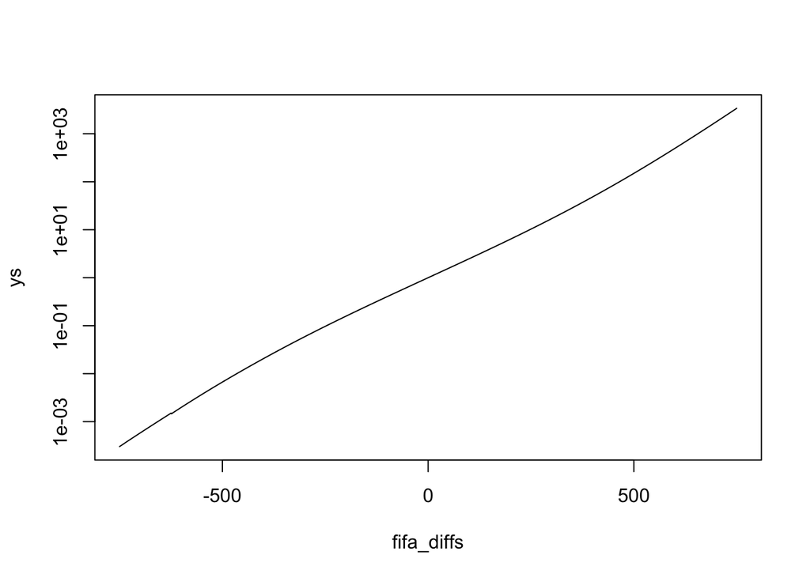

```r
fifa_diffs <- seq(-750, 750, by=1)
root_fn <- function(alpha, s){
  (1-alpha)*s+nu*(0.5-alpha)*sqrt(s)-alpha
}
find_y <- function(d){
  alpha <- 1 / (1 + 10^((d)/sigma_dash))
  uniroot(root_fn, alpha=alpha, interval = c(0,10000))[["root"]]
}
ys <- sapply(fifa_diffs, find_y)
plot(fifa_diffs, ys, log = "y", type = "l")
```

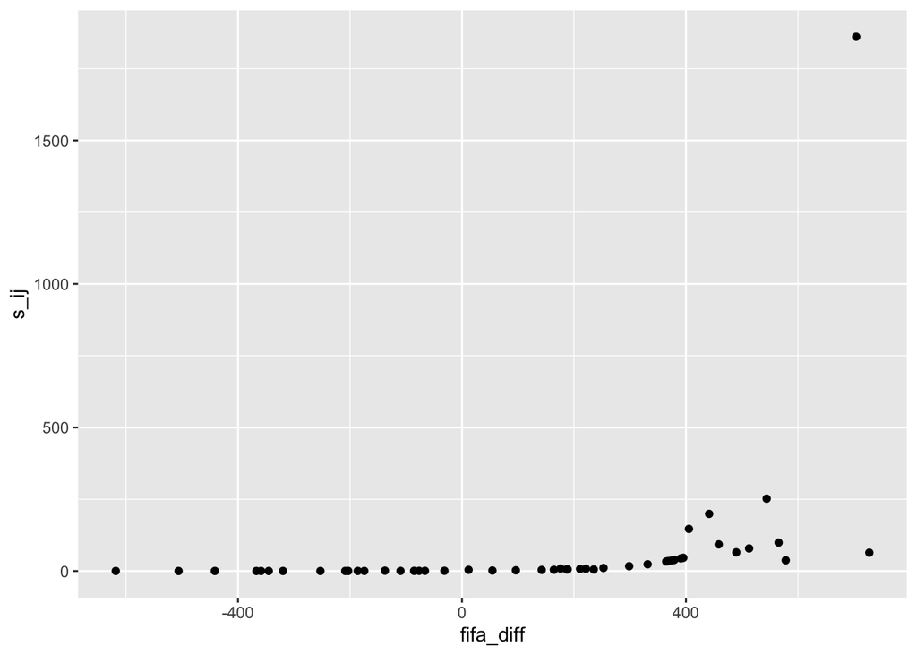

```r
estimated_df%>%
  mutate(fifa_diff = F_i - F_j)%>%
  ggplot(aes(x=fifa_diff,y=s_ij)) +
  geom_point()
```

# Intra-group strength

We then estimate the intra-group strength parameters by linear regression, starting with constructing an appropriate adjacency matrix,

```r
# I'm using Group_Winner_odds$Team here, because that's a list of all the teams

makeX_lm <- function(df){
  X_lm <- matrix(0,
                 nrow(df),
                 length(levels(factor(as.character(Group_Winner_odds$Team)))))
  colnames(X_lm) <- levels(factor(as.character(Group_Winner_odds$Team)))
  for (team in colnames(X_lm)) {
    X_lm[df$TeamName1 == team, team] <- 1
    X_lm[df$TeamName2 == team, team] <- -1
  }
  return(X_lm)
}

estimated_df$X <- makeX_lm(estimated_df)
```

then fitting the linear model.

```r
lmfit_group <- lm(logit_p_ij ~ -1 + X, data = estimated_df)

r <- coef(lmfit_group)
r[is.na(r)] <- 0
s <- exp(r)
sort(r)
```

```
## XSouth Africa      XMorocco    XArgentina  XPhilippines        XItaly
##    -4.5523458    -3.9264682    -3.0087570    -2.6561038    -1.4654829
##  XNew Zealand     XColombia        XHaiti      XNigeria       XPanama
##    -0.7964421    -0.6820832     0.0000000     0.0000000     0.0000000
##  XSouth Korea       XSweden  XSwitzerland      XVietnam       XZambia
##     0.0000000     0.0000000     0.0000000     0.0000000     0.0000000
##      XJamaica      XIreland       XNorway     XPortugal      XGermany
##     0.5444828     1.1520703     1.2672725     1.3145545     1.6804277
##   XCosta Rica    XAustralia       XCanada        XChina  XNetherlands
##     1.8533981     3.0755678     3.1354792     3.1459178     3.2819883
##      XDenmark        XJapan          XUSA       XBrazil      XEngland
##     3.8985120     4.2846193     4.7297691     4.7494910     4.9882658
##       XFrance        XSpain
##     5.0945551     6.4783571
```

Under Bradley–Terry, the probability of $i$ winning the final, given $i$ has made it to the final, is
$$q_{io} = \pi_i / (\pi_i + \pi_o),$$
where $\pi_i$ is the strength of team $i$ and $\pi_o$ is the strength of the final opponent, since there are so many permutations by which a final opponent may be determined for all teams. The opponent strength $\pi_o$ is assumed to be the same for all teams, so
$$\begin{equation}
\text{logit}(q_{io}) = \lambda_i - \lambda_o
\end{equation}$$
where $\lambda_i = \log \pi_i$. We have the intra-group strengths $s_i$, but we do not know the relative strengths of the groups. Suppose group $G$ has strength $\gamma_G$ such that $s_i = \gamma_{G(i)} \pi_i$ where $G(i)$ is $i$’s group. Then
$$\begin{equation}
\lambda_i = \log \pi_i = \log s_i - \log \gamma_{G(i)} = r_i -
\lambda_{G(i)}
\end{equation}$$
where $\lambda_{G(i)} = \log \gamma_{G(i)}$. So combining (1) and (2) we have
$$r_i - \text{logit}(q_{io}) = \lambda_{G(i)} + \lambda_o.$$
So we estimate $\lambda_o$ and the $\lambda_G$ by regressing against $r_i - \text{logit}(q_{io})$.

```r
winner <- read_csv("data/Winner odds.csv")%>%
  # filter(Odds < 100)%>%
  mutate(pi_win = 1 / Odds,
         total_prob = sum(pi_win))%>%
  mutate(pi_win = pi_win / total_prob)%>%
  select(Team, pi_win)%>%
  left_join(
    read_csv("data/Reach final odds.csv")%>%
      mutate(p_i = 1 / Odds,
             total_prob = sum(p_i))%>%
      mutate(p_i = 2*p_i / total_prob)%>%
      select(Team, p_i)%>%
      rename("pi_final" = "p_i"),
    by = "Team"
  )%>%
  # calculate the conditional probability of winning given you make the final
  mutate(q_io = pi_win / pi_final)%>%
  left_join(
    as.data.frame(r)%>%
      rownames_to_column("Team")%>%
      mutate(Team = str_remove(Team, "^X")),
    by = "Team"
  )%>%
  left_join(
    Group_Winner_odds%>%select(-Odds), by="Team"
  )

winner
```

| Team | pi_win | pi_final | q_io | r | Group |
| --- | --- | --- | --- | --- | --- |
| USA | 0.2619804 | 0.4333084 | 0.6046049 | 4.7297691 | E |
| England | 0.1571882 | 0.3066490 | 0.5125998 | 4.9882658 | D |
| Spain | 0.1347328 | 0.2301638 | 0.5853777 | 6.4783571 | C |
| Germany | 0.0943129 | 0.1993219 | 0.4731691 | 1.6804277 | H |
| Australia | 0.0725484 | 0.1423728 | 0.5095667 | 3.0755678 | B |
| France | 0.0725484 | 0.1661016 | 0.4367714 | 5.0945551 | F |
| Sweden | 0.0449109 | 0.1107344 | 0.4055735 | 0.0000000 | G |
| Netherlands | 0.0277391 | 0.0830508 | 0.3340017 | 3.2819883 | E |
| Brazil | 0.0277391 | 0.0664406 | 0.4175021 | 4.7494910 | F |
| Japan | 0.0277391 | 0.0586241 | 0.4731691 | 4.2846193 | C |
| Canada | 0.0205028 | 0.0586241 | 0.3497336 | 3.1354792 | B |
| Norway | 0.0140766 | 0.0474576 | 0.2966134 | 1.2672725 | A |
| Denmark | 0.0074852 | 0.0293120 | 0.2553611 | 3.8985120 | D |
| South Korea | 0.0037575 | 0.0049583 | 0.7578245 | 0.0000000 | H |
| Portugal | 0.0037575 | 0.0049583 | 0.7578245 | 1.3145545 | E |
| China | 0.0037575 | 0.0039706 | 0.9463381 | 3.1459178 | D |
| Italy | 0.0037575 | 0.0148748 | 0.2526082 | -1.4654829 | G |
| Switzerland | 0.0037575 | 0.0049583 | 0.7578245 | 0.0000000 | A |
| Ireland | 0.0037575 | 0.0049583 | 0.7578245 | 1.1520703 | B |
| Colombia | 0.0031333 | 0.0033110 | 0.9463381 | -0.6820832 | H |
| Argentina | 0.0018825 | 0.0033110 | 0.5685584 | -3.0087570 | G |
| New Zealand | 0.0012558 | 0.0039706 | 0.3162861 | -0.7964421 | A |
| Zambia | 0.0009422 | 0.0019892 | 0.4736418 | 0.0000000 | C |
| Haiti | 0.0009422 | 0.0019892 | 0.4736418 | 0.0000000 | D |
| Nigeria | 0.0009422 | 0.0019892 | 0.4736418 | 0.0000000 | B |
| South Africa | 0.0009422 | 0.0019892 | 0.4736418 | -4.5523458 | G |
| Morocco | 0.0009422 | 0.0019892 | 0.4736418 | -3.9264682 | H |
| Costa Rica | 0.0009422 | 0.0019892 | 0.4736418 | 1.8533981 | C |
| Jamaica | 0.0009422 | 0.0019892 | 0.4736418 | 0.5444828 | F |
| Panama | 0.0004713 | 0.0013270 | 0.3551724 | 0.0000000 | F |
| Vietnam | 0.0003771 | 0.0019892 | 0.1895703 | 0.0000000 | E |
| Philippines | 0.0002357 | 0.0013270 | 0.1776306 | -2.6561038 | A |

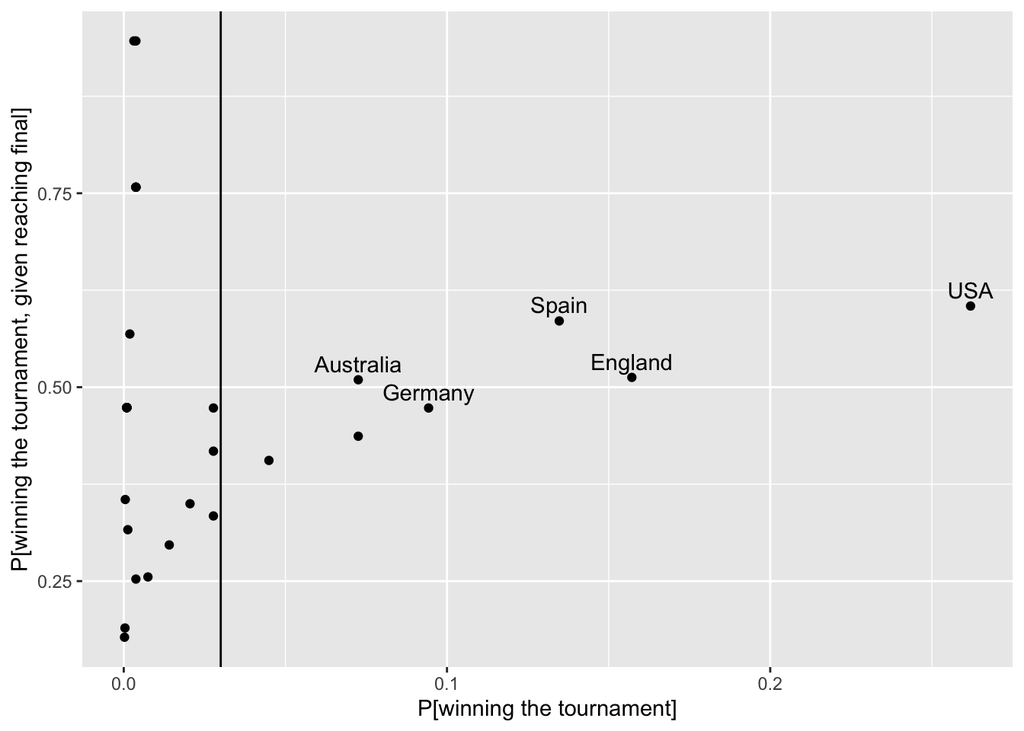

```r
winner%>%
  mutate(label = ifelse(Team %in% c("USA", "Brazil", "Germany", "England", "Australia", "Spain"), Team, "")) %>%
  ggplot(aes(x=pi_win, y=q_io, label = label)) +
  geom_point() +
  geom_vline(xintercept=0.03) +
    labs(x="P[winning the tournament]",
         y="P[winning the tournament, given reaching final]") +
  geom_text(check_overlap = TRUE, vjust=-0.5)
```

```r
y <- winner$r - qlogis(winner$q_io)

X <- matrix(0,
            nrow(winner),
            length(unique(winner$Group)))
colnames(X) <- sort(unique(winner$Group))
rownames(X) <- winner$Team
for (group in colnames(X)) {
  X[winner$Group == group, group] <- 1
}
X
```

```
##              A B C D E F G H
## USA          0 0 0 0 1 0 0 0
## England      0 0 0 1 0 0 0 0
## Spain        0 0 1 0 0 0 0 0
## Germany      0 0 0 0 0 0 0 1
## Australia    0 1 0 0 0 0 0 0
## France       0 0 0 0 0 1 0 0
## Sweden       0 0 0 0 0 0 1 0
## Netherlands  0 0 0 0 1 0 0 0
## Brazil       0 0 0 0 0 1 0 0
## Japan        0 0 1 0 0 0 0 0
## Canada       0 1 0 0 0 0 0 0
## Norway       1 0 0 0 0 0 0 0
## Denmark      0 0 0 1 0 0 0 0
## South Korea  0 0 0 0 0 0 0 1
## Portugal     0 0 0 0 1 0 0 0
## China        0 0 0 1 0 0 0 0
## Italy        0 0 0 0 0 0 1 0
## Switzerland  1 0 0 0 0 0 0 0
## Ireland      0 1 0 0 0 0 0 0
## Colombia     0 0 0 0 0 0 0 1
## Argentina    0 0 0 0 0 0 1 0
## New Zealand  1 0 0 0 0 0 0 0
## Zambia       0 0 1 0 0 0 0 0
## Haiti        0 0 0 1 0 0 0 0
## Nigeria      0 1 0 0 0 0 0 0
## South Africa 0 0 0 0 0 0 1 0
## Morocco      0 0 0 0 0 0 0 1
## Costa Rica   0 0 1 0 0 0 0 0
## Jamaica      0 0 0 0 0 1 0 0
## Panama       0 0 0 0 0 1 0 0
## Vietnam      0 0 0 0 1 0 0 0
## Philippines  1 0 0 0 0 0 0 0
```

```r
lmfit_win <- lm(y ~ X)
```

Where probability of winning is small, we make an adjustment according to a threshold, since the $q_io$ for low probability teams may be highly unreliable.

```r
cut <- subset(winner, pi_win > 0.02)

y2 <- cut$r - qlogis(cut$q_io)
X2 <- matrix(0,
            nrow(cut),
            # for columns I still need to take winner df, to ensure all groups are there
            length(unique(winner$Group)))
colnames(X2) <- sort(unique(winner$Group))
rownames(X2) <- cut$Team
for (group in colnames(X2)) {
  X2[cut$Group == group, group] <- 1
}
X2
```

```
##             A B C D E F G H
## USA         0 0 0 0 1 0 0 0
## England     0 0 0 1 0 0 0 0
## Spain       0 0 1 0 0 0 0 0
## Germany     0 0 0 0 0 0 0 1
## Australia   0 1 0 0 0 0 0 0
## France      0 0 0 0 0 1 0 0
## Sweden      0 0 0 0 0 0 1 0
## Netherlands 0 0 0 0 1 0 0 0
## Brazil      0 0 0 0 0 1 0 0
## Japan       0 0 1 0 0 0 0 0
## Canada      0 1 0 0 0 0 0 0
```

```r
lmfit_win <- lm(y2 ~ X2) # NOTE: this replaces lmfit_win above
```

```r
lambda_G <- coef(lmfit_win)
lambda_G[is.na(lambda_G)] <- 0
names(lambda_G) <- c("O", "A", "B", "C", "D", "E", "F", "G", "H")
lambda_G
```

```
##         O         A         B         C         D         E         F         G
##  1.787855  0.000000  1.608638  3.474902  3.150001  2.350750  3.427824 -1.405560
##         H
##  0.000000
```

Get the team coefficients $\lambda_i = r_i - \lambda_{G(i)}$

```r
lambda <- setNames(winner$r - lambda_G[winner$Group], winner$Team)
lambda
```

```
##          USA      England        Spain      Germany    Australia       France
##  2.379019382  1.838264614  3.003454768  1.680427728  1.466929578  1.666731005
##       Sweden  Netherlands       Brazil        Japan       Canada       Norway
##  1.405559642  0.931238610  1.321666930  0.809717027  1.526841011  1.267272479
##      Denmark  South Korea     Portugal        China        Italy  Switzerland
##  0.748510881  0.000000000 -1.036195231 -0.004083397 -0.059923226  0.000000000
##      Ireland     Colombia    Argentina  New Zealand       Zambia        Haiti
## -0.456567906 -0.682083154 -1.603197391 -0.796442072 -3.474902289 -3.150001148
##      Nigeria South Africa      Morocco   Costa Rica      Jamaica       Panama
## -1.608638181 -3.146786172 -3.926468206 -1.621504203 -2.883341256 -3.427824076
##      Vietnam  Philippines
## -2.350749732 -2.656103804
```

Then calculate the probabilities from the $\lambda$s

```r
probs <- plogis(outer(lambda, lambda, '-'))
probs
```

```
##                      USA     England        Spain     Germany   Australia
## USA          0.500000000 0.631987979 0.3487733655 0.667875450 0.713427611
## England      0.368012021 0.500000000 0.2377254867 0.539377506 0.591781531
## Spain        0.651226634 0.762274513 0.5000000000 0.789684886 0.822959022
## Germany      0.332124550 0.460622494 0.2103151139 0.500000000 0.553172717
## Australia    0.286572389 0.408218469 0.1770409778 0.446827283 0.500000000
## France       0.329093390 0.457221439 0.2080493510 0.496575873 0.549784847
## Sweden       0.274191440 0.393480595 0.1682760058 0.431712380 0.484662330
## Netherlands  0.190343342 0.287608794 0.1118267370 0.320998013 0.369190541
## Brazil       0.257815730 0.373648153 0.1568588749 0.411259575 0.463748062
## Japan        0.172315869 0.263365782 0.1003142533 0.295106441 0.341366051
## Canada       0.298976094 0.422767292 0.1859394363 0.461678621 0.514973380
## Norway       0.247545355 0.361007926 0.1497985043 0.398155793 0.450250878
## Denmark      0.163760714 0.251664655 0.0949238677 0.282535990 0.327741292
## South Korea  0.084786629 0.137256663 0.0472700421 0.157038839 0.187409752
## Portugal     0.031823339 0.053430642 0.0172991055 0.061999570 0.075639409
## China        0.084470303 0.136773834 0.0470864836 0.156499045 0.186788696
## Italy        0.080250924 0.130313713 0.0446434086 0.149268362 0.178454625
## Switzerland  0.084786629 0.137256663 0.0472700421 0.157038839 0.187409752
## Ireland      0.055431128 0.091551835 0.0304713634 0.105552700 0.127472059
## Colombia     0.044740558 0.074443980 0.0244698834 0.086076465 0.104423516
## Argentina    0.018303017 0.031024503 0.0098864729 0.036137236 0.044356445
## New Zealand  0.040099666 0.066937884 0.0218834789 0.077495685 0.094202278
## Zambia       0.002860422 0.004902151 0.0015339760 0.005735490 0.007090865
## Haiti        0.003954178 0.006771314 0.0021216106 0.007919872 0.009786364
## Nigeria      0.018205513 0.030861359 0.0098333563 0.035948204 0.044126387
## South Africa 0.003966861 0.006792971 0.0021284279 0.007945172 0.009817568
## Morocco      0.001822926 0.003126428 0.0009771205 0.003659014 0.004525922
## Costa Rica   0.017976964 0.030478864 0.0097088710 0.035504972 0.043586879
## Jamaica      0.005156329 0.008822347 0.0027681722 0.010315190 0.012738943
## Panama       0.002997892 0.005137241 0.0016078009 0.006010302 0.007430133
## Vietnam      0.008751249 0.014934792 0.0047059784 0.017443728 0.021506071
## Philippines  0.006463350 0.011048306 0.0034719580 0.012912899 0.015937205
##                   France      Sweden Netherlands      Brazil       Japan
## USA          0.670906610 0.725808560 0.809656658 0.742184270 0.827684131
## England      0.542778561 0.606519405 0.712391206 0.626351847 0.736634218
## Spain        0.791950649 0.831723994 0.888173263 0.843141125 0.899685747
## Germany      0.503424127 0.568287620 0.679001987 0.588740425 0.704893559
## Australia    0.450215153 0.515337670 0.630809459 0.536251938 0.658633949
## France       0.500000000 0.564924217 0.676009382 0.585420120 0.702036412
```

[output cut: 143 more lines]

```
## Switzerland  0.83500247 0.9470168 0.9685629 0.9129938   0.9343862
## Ireland      0.76222851 0.9188463 0.9512586 0.8692316   0.9002078
## Colombia     0.71898270 0.9003624 0.9396724 0.8413980   0.8780423
## Argentina    0.50457658 0.7824743 0.8611204 0.6786451   0.7413326
## New Zealand  0.69530983 0.8896233 0.9328542 0.8255350   0.8652575
## Zambia       0.13547442 0.3562768 0.4882326 0.2452418   0.3060188
## Haiti        0.17821371 0.4337273 0.5690124 0.3101857   0.3789759
## Nigeria      0.50321646 0.7815468 0.8604684 0.6774574   0.7402879
## South Africa 0.17868504 0.4345171 0.5698007 0.3108740   0.3797328
## Morocco      0.09071268 0.2605471 0.3778594 0.1714027   0.2191949
## Costa Rica   0.50000000 0.7793422 0.8589165 0.6746397   0.7378067
## Jamaica      0.22065782 0.5000000 0.6328546 0.3699127   0.4434338
## Panama       0.14108349 0.3671454 0.5000000 0.2540601   0.3161071
## Vietnam      0.32536031 0.6300873 0.7459399 0.5000000   0.5757508
## Philippines  0.26219335 0.5565662 0.6838929 0.4242492   0.5000000
```

```r
write.csv(probs, "probabilities.csv")
```